# Statistical Rethinking: Chapter 10: Counting and Classification

# Binomial regression

### Logistic regression: Prosocial chimpanzees

```r
library(rethinking)
data("chimpanzees")
d <- chimpanzees
```

Let’s fit the following model:

$$\begin{aligned}
L_i &\sim \text{Binomial}(1, p_i) \\
\text{logit}(p_i) &= \alpha + (\beta_P + \beta_{PC} C_i) P_i \\
\alpha &\sim \text{Normal}(0, 10) \\
\beta_P &\sim \text{Normal}(0, 10) \\
\beta_{PC} &\sim \text{Normal}(0, 10) \\
\end{aligned}$$

```r
# first with only an intercept
m10.1 <- map(
  alist(pulled_left ~ dbinom(1, p),
        logit(p) <- a,
        a ~ dnorm(0, 10)),
  data = d
)
precis(m10.1)
```

|  | mean | sd | 5.5% | 94.5% |
| --- | --- | --- | --- | --- |
| a | 0.32 | 0.09 | 0.18 | 0.46 |

```r
# to get the logit coefficients back into a probability scale, we need to use
# the inverse link function
logistic(c(0.18, 0.46))
```

```
[1] 0.5448789 0.6130142
```

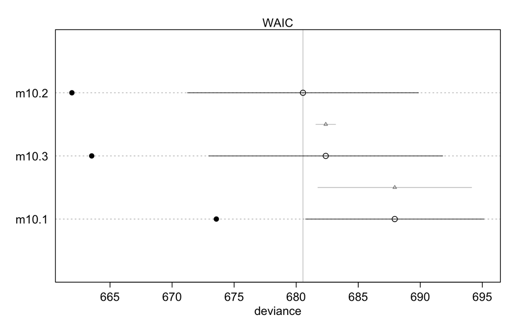

```r
m10.2 <- map(
  alist(pulled_left ~ dbinom(1, p),
        logit(p) <- a + bp * prosoc_left,
        a ~ dnorm(0, 10),
        bp ~ dnorm(0, 10)),
  data = d
)

m10.3 <- map(
  alist(pulled_left ~ dbinom(1, p),
        logit(p) <- a + (bp + bpC * condition) * prosoc_left,
        a ~ dnorm(0, 10),
        bp ~ dnorm(0, 10),
        bpC ~ dnorm(0, 10)),
  data = d
)

m10.3a <- map(
  alist(pulled_left ~ dbinom(1, p),
        logit(p) <- a + bp * prosoc_left + bpC * condition * prosoc_left,
        a ~ dnorm(0, 10),
        bp ~ dnorm(0, 10),
        bpC ~ dnorm(0, 10)),
  data = d
)

plot(compare(m10.1, m10.2, m10.3))
```

```r
precis(m10.3)
```

|  | mean | sd | 5.5% | 94.5% |
| --- | --- | --- | --- | --- |
| a | 0.05 | 0.13 | -0.15 | 0.25 |
| bp | 0.61 | 0.23 | 0.25 | 0.97 |
| bpC | -0.10 | 0.26 | -0.53 | 0.32 |

```r
precis(m10.3a)
```

|  | mean | sd | 5.5% | 94.5% |
| --- | --- | --- | --- | --- |
| a | 0.05 | 0.13 | -0.15 | 0.25 |
| bp | 0.61 | 0.23 | 0.25 | 0.97 |
| bpC | -0.10 | 0.26 | -0.53 | 0.32 |

To understand how big $0.61$ is, we need to distinguish between an absolute effect and a relative effect. An absolute effect is the change in the probability of the outcome, so it depends upon all of the parameters and it tells us the practical impact of a change in a predictor. The relative effect is just a proportional change induced by a change in the predictor.

The customary measure of relative effect for a logistic model is the proportional change in odds. Just get this by exponentiating the parameter. Odds at the ratio of the probability an event happens to the probability it does not happen. If changing the predictor `prosoc_left` from 0 to 1 increases the log-odds of pulling the left-hand lever by $0.61$, then this also implies that the odds are multiplied by:

```r
exp(0.61)
```

```
[1] 1.840431
```

This can be read as a proportional increase of 1.84 in the odds of pulling the left-hand lever. This means that the odds increase by 84%. The actual change in probability also depends on the intercept, as well as any other predictor variables. If the intercept is large enough to guarantee a pull, then increasing the odds by 84% isn’t going to make it any more guaranteed. You always need to consider absolute effects. If the constant had a value of 4, then the probability of a pull would be:

```r
logistic(4)
```

```
[1] 0.9820138
```

Adding an increase of 0.61 changes this to:

```r
logistic(4 + 0.61)
```

```
[1] 0.9901462
```

```r
# re-use the map fit to get the formula
m10.3stan <- map2stan(m10.3, data = d2, iter = 1e4, warmup = 1000)
```

```
Computing WAIC
```

Now let’s model the individual variation. We want to estimated the handedness as a distinct intercept for each individual, each actor. This could be done with a dummy variable for each individual or a vector of intercepts, one for each actor. Here is the model we will fit:

$$\begin{aligned}
L_i &\sim \text{Binomial}(1, p_i) \\
\text{logit}(p_i) &= \alpha_{ACTOR[i]} + (\beta_P + \beta_{PC} C_i) P_i \\
\alpha_{ACTOR[i]} &\sim \text{Normal}(0, 10) \\
\beta_P &\sim \text{Normal}(0, 10) \\
\beta_{PC} &\sim \text{Normal}(0, 10) \\
\end{aligned}$$

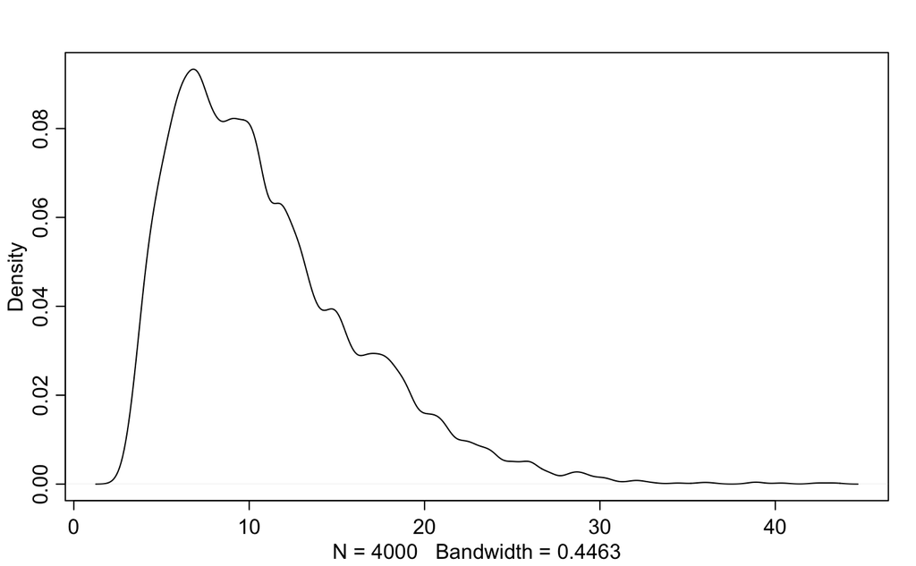

### Aggregated Binomial

Rather than having one row for each pull outcome, it could be arranged so that one row shows a count of the number of pulls each individual had. This can be calculated as follows:

|  | mean | sd | 5.5% | 94.5% |
| --- | --- | --- | --- | --- |
| a | 0.05 | 0.13 | -0.15 | 0.25 |
| bp | 0.61 | 0.23 | 0.25 | 0.97 |
| bpC | -0.10 | 0.26 | -0.53 | 0.32 |

What about when the number of trials isn’t constant?

|  | dept | applicant.gender | admit | reject | applications |
| --- | --- | --- | --- | --- | --- |
| 1 | A | male | 512 | 313 | 825 |
| 2 | A | female | 89 | 19 | 108 |
| 3 | B | male | 353 | 207 | 560 |
| 4 | B | female | 17 | 8 | 25 |
| 5 | C | male | 120 | 205 | 325 |
| 6 | C | female | 202 | 391 | 593 |

We want to see if there is gender bias in admissions. Thus, we will model the admission decisions with gender as the main predictor. We will fit two models:

1. A binomial regression that models `admit` as a function of each applicant’s gender. This will estimate the association between gender and probability of admission.
2. A binomial regression that models `admit` as a constant, ignoring gender. This will allow us to get a sense of any overfitting committed by the first model.

Here is the first model:

$$\begin{aligned}
n_{admit, i} &\sim \text{Binomial}(n_i, p_i) \\
\text{logit}(p_i) &= \alpha + \beta_m m_i \\
\alpha &\sim \text{Normal}(0, 10) \\
\beta_m &\sim \text{Normal}(0, 10)
\end{aligned}$$

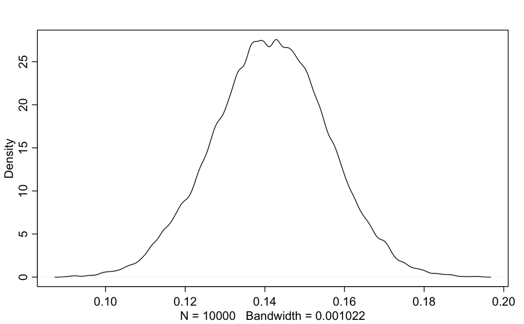

Now let’s run posterior predictions for the model.

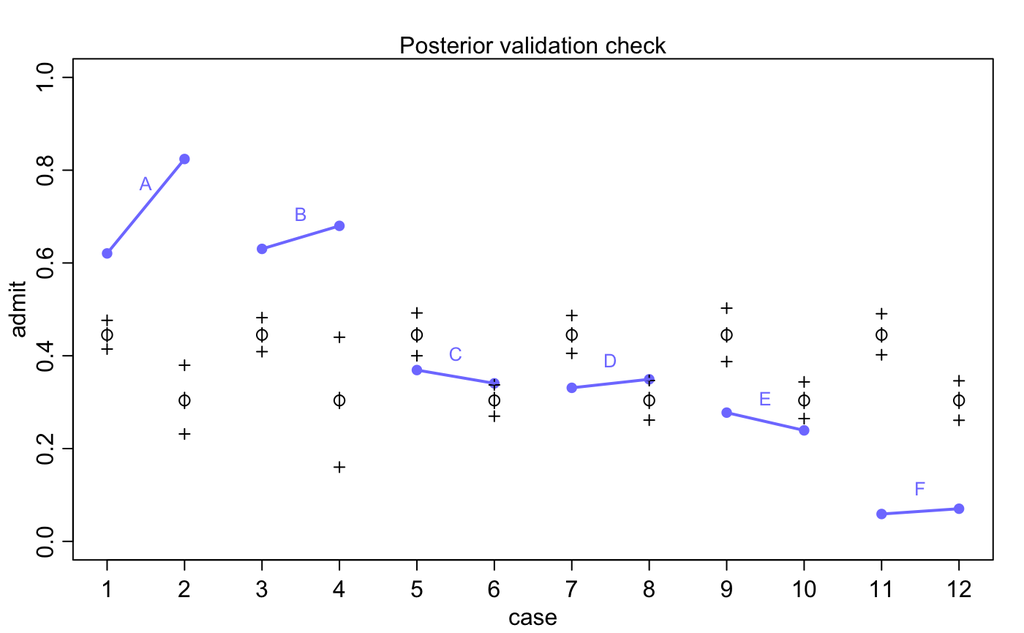

The model is very inaccurate because it does not account for the face that males and females apply to different departments at different rates. Rather than ask, “what are the average probabilities of admission for females and males across all departments?” we want to ask, “what is the average difference in probability of admission between females and males within departments?” The model below fits an intercept for each department to account for this.

$$\begin{aligned}
n_{admit, i} &\sim \text{Binomial}(n_i, p_i) \\
\text{logit}(p_i) &= \alpha_{DEPT[i]} + \beta_m m_i \\
\alpha_{DEPT[i]} &\sim \text{Normal}(0, 10) \\
\beta_m &\sim \text{Normal}(0, 10)
\end{aligned}$$

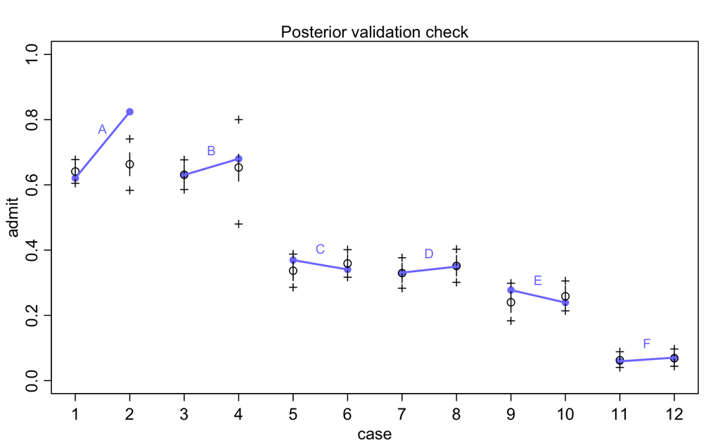

Now we check the quadratic approximation:

|  | mean | sd | 5.5% | 94.5% | n_eff | Rhat |
| --- | --- | --- | --- | --- | --- | --- |
| a[1] | 0.68 | 0.10 | 0.52 | 0.85 | 2162 | 1 |
| a[2] | 0.64 | 0.12 | 0.45 | 0.84 | 1972 | 1 |
| a[3] | -0.58 | 0.08 | -0.70 | -0.46 | 3538 | 1 |
| a[4] | -0.61 | 0.09 | -0.75 | -0.48 | 2637 | 1 |
| a[5] | -1.06 | 0.10 | -1.22 | -0.90 | 3906 | 1 |
| a[6] | -2.64 | 0.17 | -2.91 | -2.38 | 3331 | 1 |
| bm | -0.10 | 0.08 | -0.24 | 0.03 | 1743 | 1 |

# Poisson regression

When a binomial distribution has a very small probability of an event and a very large number of trials, then it takes on a special shape.

| culture | population | contact | total_tools | mean_TU |
| --- | --- | --- | --- | --- |
| Malekula | 1100 | low | 13 | 3.2 |
| Tikopia | 1500 | low | 22 | 4.7 |
| Santa Cruz | 3600 | low | 24 | 4.0 |
| Yap | 4791 | high | 43 | 5.0 |
| Lau Fiji | 7400 | high | 33 | 5.0 |
| Trobriand | 8000 | high | 19 | 4.0 |
| Chuuk | 9200 | high | 40 | 3.8 |
| Manus | 13000 | low | 28 | 6.6 |
| Tonga | 17500 | high | 55 | 5.4 |
| Hawaii | 275000 | low | 71 | 6.6 |

Now we’ll test the hypothesis that the number of tools increases with the contact rate:

$$\begin{aligned}
T_i &\sim \text{Poisson}(\lambda_i) \\
\log(\lambda_i) &= \alpha + \beta_p \log P_i + \beta_C C_i + \beta_{PC} C_i \log(P_i) \\
\alpha &\sim \text{Normal}(0, 100) \\
\beta_P &\sim \text{Normal}(0, 1) \\
\beta_C &\sim \text{Normal}(0, 1) \\
\beta_{PC} &\sim \text{Normal}(0, 1) \\
\end{aligned}$$

|  | mean | sd | 5.5% | 94.5% |
| --- | --- | --- | --- | --- |
| a | 0.94 | 0.36 | 0.37 | 1.52 |
| bp | 0.26 | 0.03 | 0.21 | 0.32 |
| bc | -0.09 | 0.84 | -1.43 | 1.25 |
| bpc | 0.04 | 0.09 | -0.10 | 0.19 |

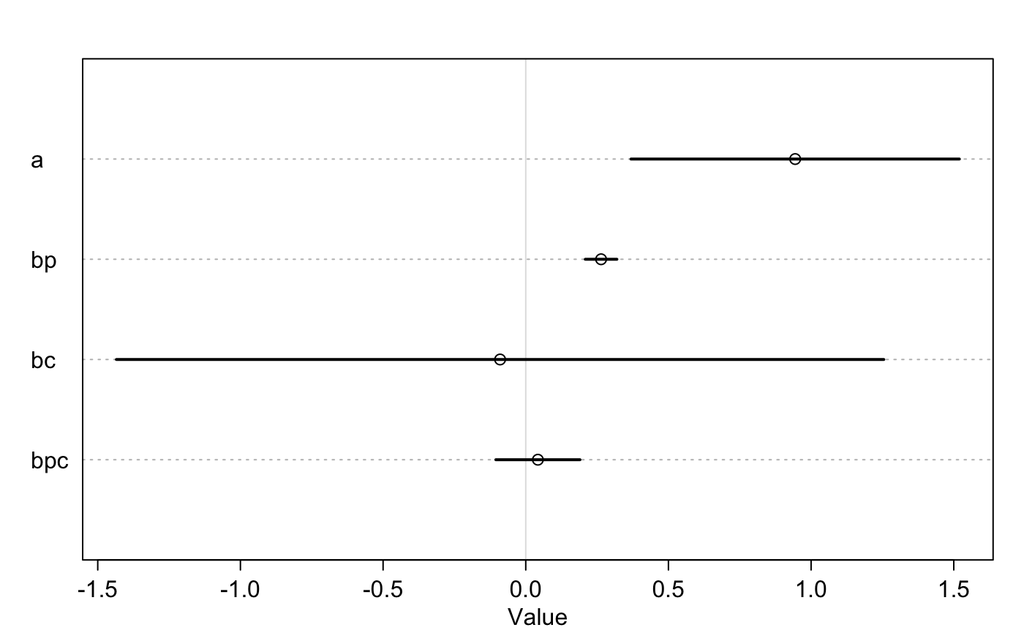

```r
precis(m10.10, corr = TRUE)

plot(precis(m10.10))
```

It is incorrect to conclude that contact rate has no impact on prediction because of the interaction term. We need to simulate.

```r
sum(diff > 0) / length(diff)
```

```
[1] 0.9856
```

Let’s fit a few models for model comparison:

|  | WAIC | SE | dWAIC | dSE | pWAIC | weight |
| --- | --- | --- | --- | --- | --- | --- |
| m10.11 | 79.2 | 11.23 | 0.0 | NA | 4.3 | 0.58 |
| m10.10 | 80.1 | 11.43 | 0.9 | 1.22 | 4.9 | 0.37 |
| m10.12 | 84.4 | 8.85 | 5.1 | 8.40 | 3.7 | 0.04 |
| m10.14 | 141.4 | 31.49 | 62.2 | 34.35 | 8.3 | 0.00 |
| m10.13 | 150.5 | 44.55 | 71.3 | 46.57 | 16.8 | 0.00 |

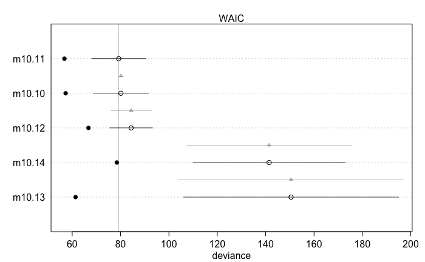

```r
islands.compare

plot(islands.compare)
```

Now check the quadratic approximations:

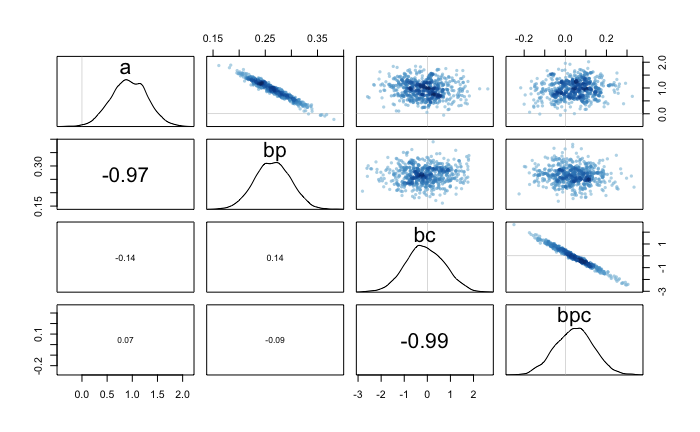

Efficiency can be imporved by centering the parameters:

|  | mean | sd | 5.5% | 94.5% | n_eff | Rhat |
| --- | --- | --- | --- | --- | --- | --- |
| a | 3.31 | 0.09 | 3.17 | 3.45 | 3860 | 1 |
| bp | 0.26 | 0.04 | 0.21 | 0.32 | 4804 | 1 |
| bc | 0.29 | 0.11 | 0.11 | 0.47 | 4135 | 1 |
| bpc | 0.07 | 0.17 | -0.20 | 0.33 | 4519 | 1 |

### Exposure and the offset

Sometimes the exposure varies across observations. When the length of observation, area of sampling, or intensity of sampling varies, the countrs we observe also naturally vary. Poisson assumes that the rate of events is constant in time. We can account for this by adding the logarithm of the exposure to the linera model. Suppose the true rate is $\lambda = 1.5$ manuscripts per day, then we can simulate a month of daily counts:

```r
y <- rpois(num_days, 1.5)
```

[output not shown]

To analyze both `y`, totaled up daily, and `y_new`, totaled up weekly, we just add the logarithm of the exposure to the linear model:

```r
post <- extract.samples(m10.15)
lambda_old <- exp(post$a)
lambda_new <- exp(post$a + post$b)
precis(data.frame(lambda_old, lambda_new))
```

```
'data.frame': 10000 obs. of 2 variables:
```

|  | mean | sd | 5.5% | 94.5% | histogram |
| --- | --- | --- | --- | --- | --- |
| lambda_old | 1.45 | 0.22 | 1.13 | 1.82 | ▁▂▇▇▃▁▁▁▁ |
| lambda_new | 0.52 | 0.14 | 0.33 | 0.76 | ▁▁▃▇▇▃▂▁▁▁▁▁ |

# Other count regressions

## Multinomial

When more than two types of unorded events are possible, and the probability of each type of event is constant across trials, then the maximum entropy distribution is the multinomial distribution.

Suppose we want to model the choice of career for a number of young adults. One of the relevant predictor variables is expected income.

|  | mean | sd | 5.5% | 94.5% |
| --- | --- | --- | --- | --- |
| b | 0.38 | 0.04 | 0.31 | 0.45 |

Multinomial outcomes can also be refactored into a series of Poisson likelihoods.

### Geometric

Sometimes a count variable is a number of events up until something happened and we often want to model the probability of that event, a kind of analysis known as event history analysis or survival analysis. When the probability of the terminating even is constant through time, and the units of time are discrete, a common likelihood function is the geometric distribution.

|  | mean | sd | 5.5% | 94.5% |
| --- | --- | --- | --- | --- |
| a | -0.17 | 7.40 | -12.00 | 11.65 |
| b | -0.02 | 0.67 | -1.09 | 1.06 |